# Project 2 - FINANCE

**DESCRIPTION**

**Problem Statement**

- Finance Industry is the biggest consumer of Data Scientists. It faces constant attack by fraudsters, who try to trick the system. Correctly identifying fraudulent transactions is often compared with finding needle in a haystack because of the low event rate.
- It is important that credit card companies are able to recognize fraudulent credit card transactions so that the customers are not charged for items that they did not purchase.
- You are required to try various techniques such as supervised models with oversampling, unsupervised anomaly detection, and heuristics to get good accuracy at fraud detection.

**Dataset Snapshot**

- The datasets contain transactions made by credit cards in September 2013 by European cardholders. This dataset represents transactions that occurred in two days, where we have 492 frauds out of 284,807 transactions. The dataset is highly unbalanced, the positive class (frauds) account for 0.172% of all transactions.

```python
# Code to show and save a rendered image in Jupyter Notebook
from PIL import Image as PILImage
import base64, io, IPython
def image_import(image_path):
    image = PILImage.open(image_path)
    output = io.BytesIO()
    image.save(output, format='PNG')
    encoded_string = base64.b64encode(output.getvalue()).decode()
    html = '<img src="data:…"/>'.format(encoded_string)
    return IPython.display.HTML(html)
```

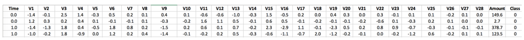

```python
image_import('data.PNG')
```

## Project Task: Week 1

**Exploratory Data Analysis (EDA):**

1. Perform an EDA on the Dataset.

   a) Check all the latent features and parameters with their mean and standard deviation. Value are close to 0 centered (mean) with unit standard deviation b) Find if there is any connection between Time, Amount, and the transaction being fraudulent.
2. Check the class count for each class. It’s a class Imbalance problem.
3. Use techniques like undersampling or oversampling before running Naïve Bayes, Logistic Regression or SVM. a. Oversampling or undersampling can be used to tackle the class imbalance problem b. Oversampling increases the prior probability of imbalanced class and in case of other classifiers, error gets multiplied as the low-proportionate class is mimicked multiple times.
4. Following are the matrices for evaluating the model performance: Precision, Recall, F1-Score, AUC-ROC curve. Use F1-Score as the evaluation criteria for this project.

### CODE:

```python
import pandas as pd
import numpy as np

import seaborn as sns
import matplotlib.pyplot as plt
%matplotlib inline

# Import the models from sklearn
from sklearn.naive_bayes import MultinomialNB
from sklearn.tree import DecisionTreeClassifier
from sklearn.neighbors import KNeighborsClassifier
from sklearn import svm
from sklearn.ensemble import RandomForestClassifier
from sklearn.ensemble import AdaBoostClassifier
from xgboost import XGBClassifier
from sklearn.linear_model import LogisticRegression

from sklearn.metrics import f1_score
from sklearn.metrics import classification_report, confusion_matrix, accuracy_score
from sklearn.model_selection import learning_curve,validation_curve
from sklearn.model_selection import KFold, cross_val_score

#objects = ('Multi-NB', 'DTs', 'AdaBoost', 'KNN', 'RF')

from sklearn.metrics import precision_recall_fscore_support as score
from sklearn.model_selection import train_test_split
from sklearn.preprocessing import StandardScaler
```

```python
data = pd.read_csv('train_data.csv')
```

```python
data.head()
```

|  | Time | V1 | V2 | V3 | V4 | V5 | V6 | V7 | V8 | V9 | ... | V21 | V22 | V23 | V24 | V25 | V26 | V27 | V28 | Amount | Class |
| --- | --- | --- | --- | --- | --- | --- | --- | --- | --- | --- | --- | --- | --- | --- | --- | --- | --- | --- | --- | --- | --- |
| 0 | 113050.0 | 0.114697 | 0.796303 | -0.149553 | -0.823011 | 0.878763 | -0.553152 | 0.939259 | -0.108502 | 0.111137 | ... | -0.335776 | -0.807853 | -0.055940 | -1.025281 | -0.369557 | 0.204653 | 0.242724 | 0.085713 | 0.89 | 0 |
| 1 | 26667.0 | -0.039318 | 0.495784 | -0.810884 | 0.546693 | 1.986257 | 4.386342 | -1.344891 | -1.743736 | -0.563103 | ... | -1.377003 | -0.072200 | -0.197573 | 1.014807 | 1.011293 | -0.167684 | 0.113136 | 0.256836 | 85.00 | 0 |
| 2 | 159519.0 | 2.275706 | -1.531508 | -1.021969 | -1.602152 | -1.220329 | -0.462376 | -1.196485 | -0.147058 | -0.950224 | ... | -0.193271 | -0.103533 | 0.150945 | -0.811083 | -0.197913 | -0.128446 | 0.014197 | -0.051289 | 42.70 | 0 |
| 3 | 137545.0 | 1.940137 | -0.357671 | -1.210551 | 0.382523 | 0.050823 | -0.171322 | -0.109124 | -0.002115 | 0.869258 | ... | 0.157994 | 0.650355 | 0.034206 | 0.739535 | 0.223605 | -0.195509 | -0.012791 | -0.056841 | 29.99 | 0 |
| 4 | 63369.0 | 1.081395 | -0.502615 | 1.075887 | -0.543359 | -1.472946 | -1.065484 | -0.443231 | -0.143374 | 1.659826 | ... | 0.224157 | 0.821209 | -0.137223 | 0.986259 | 0.563228 | -0.574206 | 0.089673 | 0.052036 | 68.00 | 0 |

5 rows × 31 columns

```python
#data['Time'] = data['Time'].apply(lambda x: x.decode("utf-8"))
data['Time'] = pd.to_datetime(data['Time'], infer_datetime_format=True)
data.head()
```

|  | Time | V1 | V2 | V3 | V4 | V5 | V6 | V7 | V8 | V9 | ... | V21 | V22 | V23 | V24 | V25 | V26 | V27 | V28 | Amount | Class |
| --- | --- | --- | --- | --- | --- | --- | --- | --- | --- | --- | --- | --- | --- | --- | --- | --- | --- | --- | --- | --- | --- |
| 0 | 1970-01-01 00:00:00.000113050 | 0.114697 | 0.796303 | -0.149553 | -0.823011 | 0.878763 | -0.553152 | 0.939259 | -0.108502 | 0.111137 | ... | -0.335776 | -0.807853 | -0.055940 | -1.025281 | -0.369557 | 0.204653 | 0.242724 | 0.085713 | 0.89 | 0 |
| 1 | 1970-01-01 00:00:00.000026667 | -0.039318 | 0.495784 | -0.810884 | 0.546693 | 1.986257 | 4.386342 | -1.344891 | -1.743736 | -0.563103 | ... | -1.377003 | -0.072200 | -0.197573 | 1.014807 | 1.011293 | -0.167684 | 0.113136 | 0.256836 | 85.00 | 0 |
| 2 | 1970-01-01 00:00:00.000159519 | 2.275706 | -1.531508 | -1.021969 | -1.602152 | -1.220329 | -0.462376 | -1.196485 | -0.147058 | -0.950224 | ... | -0.193271 | -0.103533 | 0.150945 | -0.811083 | -0.197913 | -0.128446 | 0.014197 | -0.051289 | 42.70 | 0 |
| 3 | 1970-01-01 00:00:00.000137545 | 1.940137 | -0.357671 | -1.210551 | 0.382523 | 0.050823 | -0.171322 | -0.109124 | -0.002115 | 0.869258 | ... | 0.157994 | 0.650355 | 0.034206 | 0.739535 | 0.223605 | -0.195509 | -0.012791 | -0.056841 | 29.99 | 0 |
| 4 | 1970-01-01 00:00:00.000063369 | 1.081395 | -0.502615 | 1.075887 | -0.543359 | -1.472946 | -1.065484 | -0.443231 | -0.143374 | 1.659826 | ... | 0.224157 | 0.821209 | -0.137223 | 0.986259 | 0.563228 | -0.574206 | 0.089673 | 0.052036 | 68.00 | 0 |

5 rows × 31 columns

```python
data.Class.value_counts()
```

```
0    56864
1       98
Name: Class, dtype: int64
```

```python
print('No of genuine trans = {:3d}, & percentage = {:7.2f}'.format(len(data[data['Class']==0]), (len(data[data['Class']==0])*100/data['Class'].count())))
print('No of fraud trans = {:3d}, & percentage = {:7.2f}'.format(len(data[data['Class']!=0]), (len(data[data['Class']!=0])*100/data['Class'].count())))
```

```
No of genuine trans = 56864, & percentage =   99.83
No of fraud trans =  98, & percentage =    0.17
```

#### Observation1

> there are total 56962 entries, out of which 99.83% (56864) are genuine trasactions & 0.17% (98) are fraudulant transactions.

```python
data[data['Amount']==0].shape
```

```
(358, 31)
```

#### Observation 2:

> There are 358 transactions having no transaction value; hence need to be dropped

```python
data = data[data['Amount'] > 0]
```

```python
data.shape
```

```
(56604, 31)
```

```python
print('No of genuine trans = {:3d}, & percentage = {:7.2f}'.format(len(data[data['Class']==0]), (len(data[data['Class']==0])*100/data['Class'].count())))
print('No of fraud trans = {:3d}, & percentage = {:7.2f}'.format(len(data[data['Class']!=0]), (len(data[data['Class']!=0])*100/data['Class'].count())))
```

```
No of genuine trans = 56516, & percentage =   99.84
No of fraud trans =  88, & percentage =    0.16
```

#### Observation3

> there are total 56604 entries, out of which 99.84% (56516) are genuine trasactions & 0.16% (88) are fraudulant transactions.

```python
data.isnull().sum()
```

```
Time      0
V1        0
V2        0
V3        0
V4        0
V5        0
V6        0
V7        0
V8        0
V9        0
V10       0
V11       0
V12       0
V13       0
V14       0
V15       0
V16       0
V17       0
V18       0
V19       0
V20       0
V21       0
V22       0
V23       0
V24       0
V25       0
V26       0
V27       0
V28       0
Amount    0
Class     0
dtype: int64
```

```python
data.info()
```

```
<class 'pandas.core.frame.DataFrame'>
Int64Index: 56604 entries, 0 to 56961
Data columns (total 31 columns):
 #   Column  Non-Null Count  Dtype
---  ------  --------------  -----
 0   Time    56604 non-null  datetime64[ns]
 1   V1      56604 non-null  float64
 2   V2      56604 non-null  float64
 3   V3      56604 non-null  float64
 4   V4      56604 non-null  float64
 5   V5      56604 non-null  float64
 6   V6      56604 non-null  float64
 7   V7      56604 non-null  float64
 8   V8      56604 non-null  float64
 9   V9      56604 non-null  float64
```

[output cut: 23 more lines]

```python
data.describe()
```

|  | V1 | V2 | V3 | V4 | V5 | V6 | V7 | V8 | V9 | V10 | ... | V21 | V22 | V23 | V24 | V25 | V26 | V27 | V28 | Amount | Class |
| --- | --- | --- | --- | --- | --- | --- | --- | --- | --- | --- | --- | --- | --- | --- | --- | --- | --- | --- | --- | --- | --- |
| count | 56604.000000 | 56604.000000 | 56604.000000 | 56604.000000 | 56604.000000 | 56604.000000 | 56604.000000 | 56604.000000 | 56604.000000 | 56604.000000 | ... | 56604.000000 | 56604.000000 | 56604.000000 | 56604.000000 | 56604.000000 | 56604.000000 | 56604.000000 | 56604.000000 | 56604.000000 | 56604.000000 |
| mean | 0.012363 | 0.004148 | -0.006798 | -0.010986 | -0.005745 | -0.004191 | 0.001829 | -0.007179 | 0.003594 | 0.000890 | ... | -0.002451 | -0.006482 | 0.004104 | -0.001114 | -0.001196 | 0.003321 | 0.001648 | -0.001826 | 88.213207 | 0.001555 |
| std | 1.941841 | 1.613659 | 1.515070 | 1.407273 | 1.433236 | 1.359555 | 1.303099 | 1.202218 | 1.104359 | 1.094431 | ... | 0.736890 | 0.730417 | 0.622378 | 0.604419 | 0.520777 | 0.481916 | 0.417030 | 0.326040 | 258.763137 | 0.039399 |
| min | -36.510583 | -47.429676 | -48.325589 | -5.560118 | -113.743307 | -20.054615 | -28.215112 | -41.484823 | -9.481456 | -20.949192 | ... | -21.620120 | -8.593642 | -32.828995 | -2.822684 | -8.696627 | -1.778061 | -8.878665 | -15.430084 | 0.010000 | 0.000000 |
| 25% | -0.908431 | -0.604654 | -0.896594 | -0.851395 | -0.696290 | -0.770412 | -0.549923 | -0.211489 | -0.641213 | -0.536458 | ... | -0.230640 | -0.550579 | -0.160000 | -0.356958 | -0.316242 | -0.323821 | -0.070177 | -0.052244 | 5.990000 | 0.000000 |
| 50% | 0.035282 | 0.059408 | 0.168958 | -0.028411 | -0.053001 | -0.280309 | 0.040678 | 0.019149 | -0.051684 | -0.097771 | ... | -0.033104 | -0.001860 | -0.009318 | 0.039883 | 0.017145 | -0.049755 | 0.001428 | 0.011440 | 22.175000 | 0.000000 |
| 75% | 1.319127 | 0.800638 | 1.013206 | 0.727102 | 0.613209 | 0.388697 | 0.570771 | 0.324250 | 0.601135 | 0.446746 | ... | 0.184571 | 0.523249 | 0.150216 | 0.437613 | 0.348382 | 0.243999 | 0.091168 | 0.077634 | 78.030000 | 0.000000 |
| max | 2.446505 | 18.902453 | 3.985446 | 15.304184 | 29.016124 | 73.301626 | 120.589494 | 18.282168 | 10.370658 | 15.236028 | ... | 22.614889 | 6.790452 | 20.803344 | 4.584549 | 7.519589 | 3.517346 | 31.612198 | 22.620072 | 25691.160000 | 1.000000 |

8 rows × 30 columns

```python
data['Amount'].describe()
```

```
count    56604.000000
mean        88.213207
std        258.763137
min          0.010000
25%          5.990000
50%         22.175000
75%         78.030000
max      25691.160000
Name: Amount, dtype: float64
```

### Observation 4

> The overall transaction amount varies from 0.01 to 25691 with a mean of 88.21

```python
data.groupby('Class')['Amount'].describe()
```

| Class | count | mean | std | min | 25% | 50% | 75% | max |
| --- | --- | --- | --- | --- | --- | --- | --- | --- |
| 0 | 56516.0 | 88.174166 | 258.802616 | 0.01 | 5.99 | 22.19 | 78.00 | 25691.16 |
| 1 | 88.0 | 113.286364 | 231.986824 | 0.68 | 1.00 | 8.42 | 106.62 | 1402.16 |

### Observation 5

> Geniune transaction amount ranges from **0.01 to 25691** with a mean of `88.17` &

> Fraudulant transaction amount ranges from **0.68 to 1402** with a mean of `113.28`

```python
data.groupby('Class').mean()
```

| Class | V1 | V2 | V3 | V4 | V5 | V6 | V7 | V8 | V9 | V10 | ... | V20 | V21 | V22 | V23 | V24 | V25 | V26 | V27 | V28 | Amount |
| --- | --- | --- | --- | --- | --- | --- | --- | --- | --- | --- | --- | --- | --- | --- | --- | --- | --- | --- | --- | --- | --- |
| 0 | 0.019608 | -0.000863 | 0.003789 | -0.017984 | -0.001223 | -0.001747 | 0.009603 | -0.009243 | 0.007297 | 0.009183 | ... | -0.002155 | -0.003354 | -0.006585 | 0.004240 | -0.000936 | -0.001261 | 0.003242 | 0.001325 | -0.001896 | 88.174166 |
| 1 | -4.640852 | 3.222519 | -6.805551 | 4.483386 | -2.910054 | -1.573701 | -4.990811 | 1.318206 | -2.374255 | -5.325134 | ... | 0.255424 | 0.577574 | 0.060176 | -0.083486 | -0.115645 | 0.040178 | 0.054521 | 0.209230 | 0.043648 | 113.286364 |

2 rows × 29 columns

*Graphical Representation*

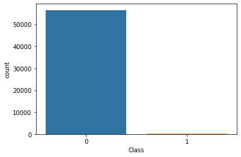

```python
sns.countplot(data['Class'])
```

```python
#data.groupby('Class').describe()
#data.groupby('Class').size().plot(kind='bar', color=['lightskyblue', 'gold'])
#plt.title('Transaction Status')
```

```python
data.groupby('Class')['Amount'].sum()
```

```
Class
0    4.983251e+06
1    9.969200e+03
Name: Amount, dtype: float64
```

### Observation 6

> Total Amount transacted geniunely is `4,983,251 (99.8%)`

> Total Amount transacted fraudulantly is `9,969 (0.2%)`

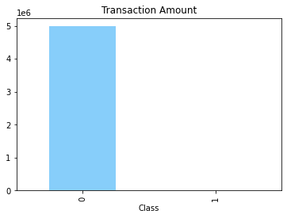

```python
data.groupby('Class')['Amount'].sum().plot(kind='bar', color=['lightskyblue', 'gold'])
plt.title('Transaction Amount')
```

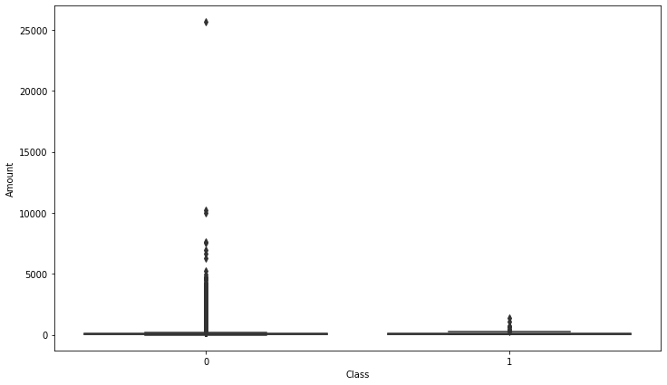

```python
plt.figure(figsize = (12,7))
sns.boxplot(x='Class', y='Amount', data=data, palette = 'winter')
```

### Inference

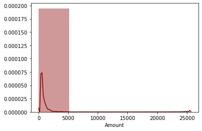

```python
sns.distplot(data['Amount'],kde=True,color='darkred', bins=5)
```

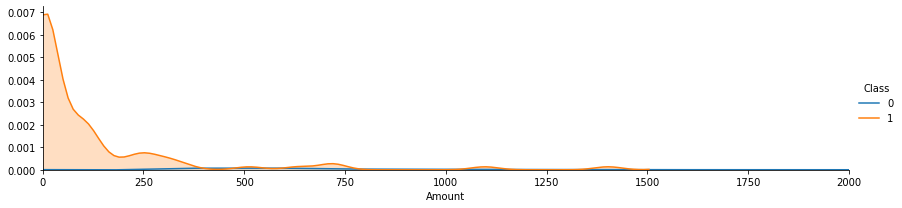

```python
fig = sns.FacetGrid(data, hue='Class', aspect=4)
fig.map(sns.kdeplot, 'Amount',shade=True)
#maxamt = data['Amount'].mean()
fig.set(xlim = (0,2000))
fig.add_legend()
```

## Project Task: Week 2

**Modeling Techniques:**

- Try out models like Naive Bayes, Logistic Regression or SVM. Find out which one performs the best
- Use different Tree-based classifiers like Random Forest and XGBoost.

  ```
  a.    Remember Tree-based classifiers work on two ideologies: Bagging or Boosting
  b.    Tree-based classifiers have fine-tuning parameters which takes care of the imbalanced class. Random-Forest and XGBboost.
  ```

- Compare the results of 1 with 2 and check if there is any incremental gain.

```python
cols = ['Time', 'Class']
```

```python
X = data.drop(cols, axis=1)
y = data['Class']
```

**LOGISTIC REGRESSION**

```python
from sklearn import metrics
X_train, X_test, y_train, y_test = train_test_split(X, y, test_size=0.3, random_state=0)
```

```python
logreg = LogisticRegression()
logreg.fit(X_train, y_train)
```

```
LogisticRegression(C=1.0, class_weight=None, dual=False, fit_intercept=True,
                   intercept_scaling=1, l1_ratio=None, max_iter=100,
                   multi_class='auto', n_jobs=None, penalty='l2',
                   random_state=None, solver='lbfgs', tol=0.0001, verbose=0,
                   warm_start=False)
```

```python
y_pred = logreg.predict(X_test)
print('Accuracy of logistic regression classifier on test set: {:.2f}'.format(logreg.score(X_test, y_test)))
```

```
Accuracy of logistic regression classifier on test set: 1.00
```

```python
from sklearn.metrics import confusion_matrix
confusion_matrix = confusion_matrix(y_test, y_pred)
print(confusion_matrix)
```

```
[[16953     3]
 [   14    12]]
```

```python
print(classification_report(y_test, y_pred))
```

```
              precision    recall  f1-score   support

           0       1.00      1.00      1.00     16956
           1       0.80      0.46      0.59        26

    accuracy                           1.00     16982
   macro avg       0.90      0.73      0.79     16982
weighted avg       1.00      1.00      1.00     16982
```

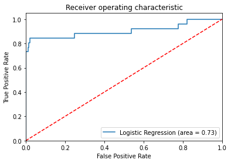

```python
from sklearn.metrics import roc_auc_score
from sklearn.metrics import roc_curve
logit_roc_auc = roc_auc_score(y_test, logreg.predict(X_test))
fpr, tpr, thresholds = roc_curve(y_test, logreg.predict_proba(X_test)[:,1])
plt.figure()
plt.plot(fpr, tpr, label='Logistic Regression (area = %0.2f)' % logit_roc_auc)
plt.plot([0, 1], [0, 1],'r--')
plt.xlim([0.0, 1.0])
plt.ylim([0.0, 1.05])
plt.xlabel('False Positive Rate')
plt.ylabel('True Positive Rate')
plt.title('Receiver operating characteristic')
plt.legend(loc="lower right")
plt.savefig('Log_ROC')
plt.show()
```

#### Observation 7

> Logistic Regression Accuracy score is `100%` with f1-score for Genuine transaction as `1` & fraudulant transaction as `0.59`

**RANDOMFOREST**

```python
rf = RandomForestClassifier(n_estimators=500, max_depth=12, n_jobs=-1)
rf_model = rf.fit(X_train, y_train)
y_pred = rf_model.predict(X_test)
```

```python
print('f1 score:',f1_score(y_pred,y_test))
print("Accuracy score:", accuracy_score(y_pred,y_test))
```

```
f1 score: 0.7727272727272727
Accuracy score: 0.9994111412083383
```

**NAIVE-BAYES**

```python
from sklearn.naive_bayes import GaussianNB
model = GaussianNB()
nb_model = model.fit(X_train, y_train)


y_pred = nb_model.predict(X_test)

print('f1 score:',f1_score(y_pred,y_test))
print("Accuracy score:", accuracy_score(y_pred,y_test))
```

```
f1 score: 0.10864197530864197
Accuracy score: 0.9787421976210104
```

**XGBoost**

```python
from xgboost import XGBClassifier
mdl_xgb = XGBClassifier(n_estimators = 100, learning_rate = 0.1, max_depth =10)
mdl_xgb.fit(X_train, y_train)
y_pred = mdl_xgb.predict(X_test)

print('f1 score:',f1_score(y_pred,y_test))
print("Accuracy score:", accuracy_score(y_pred,y_test))
```

```
f1 score: 0.7999999999999999
Accuracy score: 0.9994700270875044
```

**ADdaBoost Classifier**

```python
mdl_adb = AdaBoostClassifier(n_estimators = 100, learning_rate = 0.1)
mdl_adb.fit(X_train, y_train)
y_pred = mdl_adb.predict(X_test)

print('f1 score:',f1_score(y_pred,y_test))
print("Accuracy score:", accuracy_score(y_pred,y_test))
```

```
f1 score: 0.7000000000000001
Accuracy score: 0.9992933694500059
```

**SVM CLASSIFIER**

```python
from sklearn import svm
clf = svm.SVC(kernel='linear') # Linear Kernel
clf.fit(X_train, y_train)
y_pred = clf.predict(X_test)

print('f1 score:',f1_score(y_pred,y_test))
print("Accuracy score:", accuracy_score(y_pred,y_test))
```

```
f1 score: 0.7272727272727274
Accuracy score: 0.9992933694500059
```

### Observation7

[output not shown]

# Balancing unbalanced data

```python
from imblearn.over_sampling import SMOTE
from sklearn.model_selection import GridSearchCV
```

```python
smote = SMOTE(random_state=42)
X_res, y_res = smote.fit_resample(X, y)
```

```python
X_train, X_test, y_train, y_test = train_test_split(X_res,y_res,test_size=0.3,random_state=42)
```

```python
from sklearn.ensemble import GradientBoostingClassifier, RandomForestClassifier
from sklearn.metrics import make_scorer,confusion_matrix, accuracy_score, f1_score, classification_report,roc_auc_score
from sklearn.model_selection import GridSearchCV
```

**RANDOM FOREST-SMOTE**

```python
rf = RandomForestClassifier()
rf.fit(X_train,y_train)
y_pred1 = rf.predict(X_test)

#print('f1 score:',f1_score(y_pred,y_test))
#print("Accuracy score:", accuracy_score(y_pred,y_test))
```

```python
print('f1 score:',f1_score(y_pred1,y_test))
print("Accuracy score:", accuracy_score(y_pred1,y_test))
```

```
f1 score: 0.9997626676159962
Accuracy score: 0.9997640813919197
```

**NAIVE-BAYES-SMOTE**

```python
from sklearn.naive_bayes import GaussianNB
model = GaussianNB()
nb_model = model.fit(X_train, y_train)


y_pred = nb_model.predict(X_test)

print('f1 score:',f1_score(y_pred,y_test))
print("Accuracy score:", accuracy_score(y_pred,y_test))
```

```
f1 score: 0.9162363018012345
Accuracy score: 0.9215570628133294
```

**LOGISTIC-REGRESSION_SMOTE**

```python
logreg = LogisticRegression()
logreg.fit(X_train, y_train)
y_pred = logreg.predict(X_test)

print('f1 score:',f1_score(y_pred,y_test))
print("Accuracy score:", accuracy_score(y_pred,y_test))
```

```
f1 score: 0.9765241346269014
Accuracy score: 0.9768799764081392
```

**SVM-SMOTE**

```python
from sklearn import svm
clf = svm.SVC(kernel='linear') # Linear Kernel
clf.fit(X_train, y_train)
y_pred = clf.predict(X_test)

print('f1 score:',f1_score(y_pred,y_test))
print("Accuracy score:", accuracy_score(y_pred,y_test))
```

[output not shown]

**XGBoost-SMOTE**

```python
from xgboost import XGBClassifier
mdl_xgb = XGBClassifier(n_estimators = 100, learning_rate = 0.1, max_depth =10)
mdl_xgb.fit(X_train, y_train)
y_pred = mdl_xgb.predict(X_test)

print('f1 score:',f1_score(y_pred,y_test))
print("Accuracy score:", accuracy_score(y_pred,y_test))
```

```
f1 score: 0.9995550677780084
Accuracy score: 0.9995576526098496
```

**MLP Classifier-SMOTE**

```python
from sklearn.neural_network import MLPClassifier
```

```python
Mclf = MLPClassifier(hidden_layer_sizes=(10,10,10), max_iter=50, alpha=0.001,
 solver='sgd', verbose=10, random_state=21,tol=0.00000000001)
Mclf.fit(X_train, y_train)
y_pred = Mclf.predict(X_test)
print(confusion_matrix(y_test, y_pred))
print(classification_report(y_test, y_pred))
print("Accuracy:",metrics.accuracy_score(y_test, y_pred))
```

```
Iteration 1, loss = inf
Iteration 2, loss = inf
Iteration 3, loss = inf
Iteration 4, loss = 0.24512617
Iteration 5, loss = 0.21577234
Iteration 6, loss = inf
Iteration 7, loss = inf
Iteration 8, loss = 0.15210003
Iteration 9, loss = inf
Iteration 10, loss = inf
Iteration 11, loss = inf
Iteration 12, loss = inf
Iteration 13, loss = 0.12898676
Iteration 14, loss = inf
Iteration 15, loss = inf
Iteration 16, loss = 0.09764749
Iteration 17, loss = inf
Iteration 18, loss = inf
Iteration 19, loss = inf
Iteration 20, loss = inf
Iteration 21, loss = inf
Iteration 22, loss = inf
Iteration 23, loss = inf
Iteration 24, loss = inf
Iteration 25, loss = inf
Iteration 26, loss = inf
Iteration 27, loss = inf
Training loss did not improve more than tol=0.000000 for 10 consecutive epochs. Stopping.
[[16753   307]
 [  542 16308]]
              precision    recall  f1-score   support

           0       0.97      0.98      0.98     17060
           1       0.98      0.97      0.97     16850

    accuracy                           0.97     33910
   macro avg       0.98      0.97      0.97     33910
weighted avg       0.98      0.97      0.97     33910

Accuracy: 0.9749631377174874
```

### Observation 8

[output not shown]

## Project Task: Week 3

**Applying ANN:**

1. Use ANN (Artificial Neural Network) to identify fradulent and non-fradulent. a) Fine-tune number of layers b) Number of Neurons in each layers c) Experiment in batch-size d) Experiment with number of epochs. Check the observations in loss and accuracy e) Play with different Learning Rate variants of Gradient Descent like Adam, SGD, RMS-prop f) Find out which activation performs best for this use case and why? g) Check Confusion Matrix, Precision, Recall and F1-Score
2. Try out Dropout for ANN. How is it performed? Compare model performance with the traditional ML based prediction models from above.
3. Find the best setting of neural net that can be best classified as fraudulent and non-fraudulent transactions. Use techniques like Grid Search, Cross-Validation and Random search.

**Anomaly Detection:**

1. Implement anomaly detection algorithms. a) Assume that the data is coming from a single or a combination of multivariate Gaussian b) Formalize a scoring criterion, which gives a scoring probability for the given data point whether it belongs to the multivariate Gaussian or Normal Distribution fitted in a)

**ANN CLASSIFIER**

```python
import tensorflow as tf
```

```python
X_train.shape
```

```
(79122, 29)
```

### ARTIFICIAL NEURAL NETWORK MODELLING

**MODEL DETAILS:**

**BUILD THE GRAPH**

```python
#Initialize Sequential model
model = tf.keras.models.Sequential()
model.add(tf.keras.layers.Reshape((29,),input_shape=(29,)))
tf.keras.layers.Dropout(0.4)

#Normalize the data
model.add(tf.keras.layers.BatchNormalization())
```

```python
#Add 1st hidden layer
model.add(tf.keras.layers.Dense(200, activation='relu'))
tf.keras.layers.LeakyReLU(alpha=0.3)
tf.keras.layers.Dropout(0.4)
```

```
<tensorflow.python.keras.layers.core.Dropout at 0x7fefaa90af90>
```

```python
#Add 2nd hidden layer
model.add(tf.keras.layers.Dense(100, activation='relu'))
tf.keras.layers.LeakyReLU(alpha=0.3)
tf.keras.layers.Dropout(0.4)
```

```
<tensorflow.python.keras.layers.core.Dropout at 0x7fefaa81e9d0>
```

```python
#Add 3rd hidden layer
model.add(tf.keras.layers.Dense(60, activation='relu'))
tf.keras.layers.LeakyReLU(alpha=0.3)
tf.keras.layers.Dropout(0.4)
```

```
<tensorflow.python.keras.layers.core.Dropout at 0x7fefaa814490>
```

```python
#Add 4th hidden layer
model.add(tf.keras.layers.Dense(30, activation='relu'))
tf.keras.layers.LeakyReLU(alpha=0.3)
tf.keras.layers.Dropout(0.4)
```

```
<tensorflow.python.keras.layers.core.Dropout at 0x7fefaa8b67d0>
```

```python
#Add OUTPUT layer
model.add(tf.keras.layers.Dense(1, activation='sigmoid'))
```

```python
#Create optimizer with non-default learning rate
sgd_optimizer = tf.keras.optimizers.SGD(lr=0.3)

#Compile the model
model.compile(optimizer=sgd_optimizer, loss='binary_crossentropy', metrics=['accuracy'])
```

**MODEL SUMMARY**

```python
model.summary()
```

```
Model: "sequential"
_________________________________________________________________
Layer (type)                 Output Shape              Param #
=================================================================
reshape (Reshape)            (None, 29)                0
_________________________________________________________________
batch_normalization (BatchNo (None, 29)                116
_________________________________________________________________
dense (Dense)                (None, 200)               6000
_________________________________________________________________
dense_1 (Dense)              (None, 100)               20100
_________________________________________________________________
dense_2 (Dense)              (None, 60)                6060
_________________________________________________________________
dense_3 (Dense)              (None, 30)                1830
_________________________________________________________________
dense_4 (Dense)              (None, 1)                 31
=================================================================
Total params: 34,137
Trainable params: 34,079
Non-trainable params: 58
_________________________________________________________________
```

*Train the Model*

```python
model.fit(X_train,y_train,
          validation_data=(X_test,y_test),
          epochs=30,
          batch_size=128)
```

```
Train on 79122 samples, validate on 33910 samples
```

```
<tensorflow.python.keras.callbacks.History at 0x7fefa865dc50>
```

### Inference

```python
model.save('mnist_creditrans_dnn_v1.h5')
```

### Project Task: Week 4

**Inference and Observations:**

1. Visualize the scores for Fraudulent and Non-Fraudulent transactions.
2. Find out the threshold value for marking or reporting a transaction as fraudulent in your anomaly detection system.
3. Can this score be used as an engineered feature in the models developed previously? Are there any incremental gains in F1-Score? Why or Why not?
4. Be as creative as possible in finding other interesting insights.

```python
y_prd = model.predict_classes(X_test, verbose=1)
```

```python
prdn = pd.DataFrame(y_prd, columns = ['Predicted'])
prdn
```

|  | Predicted |
| --- | --- |
| 0 | 1 |
| 1 | 0 |
| 2 | 0 |
| 3 | 0 |
| 4 | 0 |
| ... | ... |
| 33905 | 0 |
| 33906 | 1 |
| 33907 | 1 |
| 33908 | 1 |
| 33909 | 0 |

33910 rows × 1 columns

```python
y_pred_prob = model.predict_proba(X_test)
print(y_pred_prob)
```

```
[[1.0000000e+00]
 [1.2559501e-06]
 [4.2097126e-09]
 ...
 [1.0000000e+00]
 [1.0000000e+00]
 [2.2930544e-09]]
```

```python
scr = pd.DataFrame(y_pred_prob, columns = ['Score'])
scr
```

|  | Score |
| --- | --- |
| 0 | 1.000000e+00 |
| 1 | 1.255950e-06 |
| 2 | 4.209713e-09 |
| 3 | 3.794535e-07 |
| 4 | 1.192711e-06 |
| ... | ... |
| 33905 | 2.269227e-07 |
| 33906 | 9.999962e-01 |
| 33907 | 1.000000e+00 |
| 33908 | 1.000000e+00 |
| 33909 | 2.293054e-09 |

33910 rows × 1 columns

```python
y_test.shape, scr.shape, prdn.shape
```

```
((33910,), (33910, 1), (33910, 1))
```

```python
sp = pd.merge(scr, prdn, left_index=True, right_index=True)
```

```python
test_clas = pd.DataFrame(y_test)
```

```python
test_clas = test_clas.reset_index()
del test_clas['index']
```

```python
test_clas
```

|  | Class |
| --- | --- |
| 0 | 1 |
| 1 | 0 |
| 2 | 0 |
| 3 | 0 |
| 4 | 0 |
| ... | ... |
| 33905 | 0 |
| 33906 | 1 |
| 33907 | 1 |
| 33908 | 1 |
| 33909 | 0 |

33910 rows × 1 columns

```python
cmp =  pd.merge(test_clas, sp, left_index=True, right_index=True)
cmp
```

|  | Class | Score | Predicted |
| --- | --- | --- | --- |
| 0 | 1 | 1.000000e+00 | 1 |
| 1 | 0 | 1.255950e-06 | 0 |
| 2 | 0 | 4.209713e-09 | 0 |
| 3 | 0 | 3.794535e-07 | 0 |
| 4 | 0 | 1.192711e-06 | 0 |
| ... | ... | ... | ... |
| 33905 | 0 | 2.269227e-07 | 0 |
| 33906 | 1 | 9.999962e-01 | 1 |
| 33907 | 1 | 1.000000e+00 | 1 |
| 33908 | 1 | 1.000000e+00 | 1 |
| 33909 | 0 | 2.293054e-09 | 0 |

33910 rows × 3 columns

```python
cmp['Class'].value_counts(), cmp['Predicted'].value_counts()
```

```
(0    17060
 1    16850
 Name: Class, dtype: int64,
 0    17048
 1    16862
 Name: Predicted, dtype: int64)
```

```python
cmp['diff'] = cmp['Predicted'] - cmp['Class']
cmp
```

|  | Class | Score | Predicted | diff |
| --- | --- | --- | --- | --- |
| 0 | 1 | 1.000000e+00 | 1 | 0 |
| 1 | 0 | 1.255950e-06 | 0 | 0 |
| 2 | 0 | 4.209713e-09 | 0 | 0 |
| 3 | 0 | 3.794535e-07 | 0 | 0 |
| 4 | 0 | 1.192711e-06 | 0 | 0 |
| ... | ... | ... | ... | ... |
| 33905 | 0 | 2.269227e-07 | 0 | 0 |
| 33906 | 1 | 9.999962e-01 | 1 | 0 |
| 33907 | 1 | 1.000000e+00 | 1 | 0 |
| 33908 | 1 | 1.000000e+00 | 1 | 0 |
| 33909 | 0 | 2.293054e-09 | 0 | 0 |

33910 rows × 4 columns

```python
cmp.groupby('Predicted')['Score'].describe()
```

| Predicted | count | mean | std | min | 25% | 50% | 75% | max |
| --- | --- | --- | --- | --- | --- | --- | --- | --- |
| 0 | 17048.0 | 0.000109 | 0.004473 | 0.000000 | 3.165267e-11 | 5.316291e-09 | 3.138573e-07 | 0.411922 |
| 1 | 16862.0 | 0.999903 | 0.001214 | 0.904792 | 9.999435e-01 | 9.999964e-01 | 1.000000e+00 | 1.000000 |

### Observation

```python
error = cmp[cmp['diff'] != 0]
```

```python
err = error.drop('diff', axis = 1)
err
```

|  | Class | Score | Predicted |
| --- | --- | --- | --- |
| 576 | 0 | 0.953506 | 1 |
| 2005 | 0 | 0.920920 | 1 |
| 12725 | 0 | 0.999872 | 1 |
| 15242 | 0 | 0.998861 | 1 |
| 15726 | 0 | 0.904792 | 1 |
| 16120 | 0 | 0.929336 | 1 |
| 23029 | 0 | 0.999759 | 1 |
| 24273 | 0 | 0.999869 | 1 |
| 26153 | 0 | 0.991461 | 1 |
| 29782 | 0 | 0.998434 | 1 |
| 30508 | 0 | 0.999943 | 1 |
| 33658 | 0 | 0.998511 | 1 |

```python
len(err)
```

```
12
```

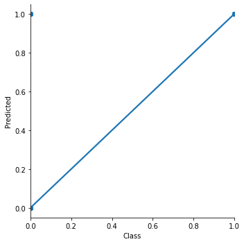

```python
sns.lmplot(x='Class', y='Predicted',data=cmp)
```

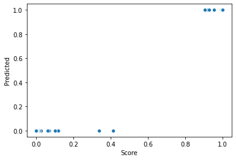

```python
sns.scatterplot(x='Score', y='Predicted',data=cmp)
```

### Observation

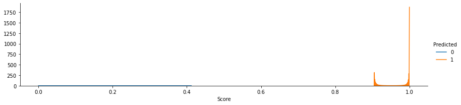

```python
fig = sns.FacetGrid(cmp, hue='Predicted', aspect=4)
fig.map(sns.kdeplot, 'Score',shade=True)
#maxamt = data['Amount'].mean()
#fig.set(xlim = (0,2000))
fig.add_legend()
```

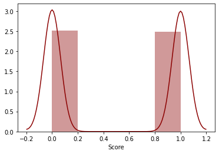

```python
sns.distplot(cmp['Score'],kde=True, color='darkred', bins=5)
```

# THE END

```python
val_data = pd.read_csv('test_data.csv')
```

```python
val_data.columns
```

```
Index(['Time', 'V1', 'V2', 'V3', 'V4', 'V5', 'V6', 'V7', 'V8', 'V9', 'V10',
       'V11', 'V12', 'V13', 'V14', 'V15', 'V16', 'V17', 'V18', 'V19', 'V20',
       'V21', 'V22', 'V23', 'V24', 'V25', 'V26', 'V27', 'V28', 'Amount'],
      dtype='object')
```

```python
val_data = val_data[val_data['Amount'] > 0]
```

```python
X_vald = data.drop(cols, axis=1)
```

```python
X_vald.shape
```

```
(56604, 29)
```

```python
val_prd = model.predict_classes(X_vald, verbose=1)
```

```python
prd = pd.DataFrame(val_prd, columns = ['prd_val'])
prd
```

|  | prd_val |
| --- | --- |
| 0 | 0 |
| 1 | 0 |
| 2 | 0 |
| 3 | 0 |
| 4 | 0 |
| ... | ... |
| 56599 | 0 |
| 56600 | 0 |
| 56601 | 0 |
| 56602 | 0 |
| 56603 | 0 |

56604 rows × 1 columns

```python
print('Predicted genuine trans = {:3d}, & percentage = {:7.2f}'.format(len(prd[prd['prd_val']==0]), (len(prd[prd['prd_val']==0])*100/prd['prd_val'].count())))
print('Predicted fraud trans = {:3d}, & percentage = {:7.2f}'.format(len(prd[prd['prd_val']!=0]), (len(prd[prd['prd_val']!=0])*100/prd['prd_val'].count())))
```

```
Predicted genuine trans = 56495, & percentage =   99.81
Predicted fraud trans = 109, & percentage =    0.19
```